# Problem Description

You, a clever post-apocalyptic survivor, have just successfully used quantum algorithms in an abandoned warehouse to find a supply combination that maximizes value. Now, your next challenge has arrived: you need to transport these precious supplies safely back to headquarters.

This is the well-known Traveling Salesman Problem (Traveling Salesman Problem, TSP). We will use two algorithms to assist your decision-making:

Simulated Annealing (Simulated Annealing, SA)

Quantum-Inspired Simulated Annealing (Quantum-Inspired Simulated Annealing, SQA)

```python
!pip install numpy dimod openjij matplotlib
```

[output not shown]

# Outpost Map and Route Planning

```
TSP Distance Matrix:
[[ 0.    5.83  8.25 10.82 10.77 11.05 13.   12.37]
 [ 5.83  0.    5.83  5.    7.07  6.32  7.28  9.22]
 [ 8.25  5.83  0.    7.28  2.83 11.4  10.44  4.12]
 [10.82  5.    7.28  0.    6.4   5.39  3.16  8.49]
 [10.77  7.07  2.83  6.4   0.   11.4   9.43  2.24]
 [11.05  6.32 11.4   5.39 11.4   0.    4.12 13.6 ]
 [13.    7.28 10.44  3.16  9.43  4.12  0.   11.4 ]
 [12.37  9.22  4.12  8.49  2.24 13.6  11.4   0.  ]]
```

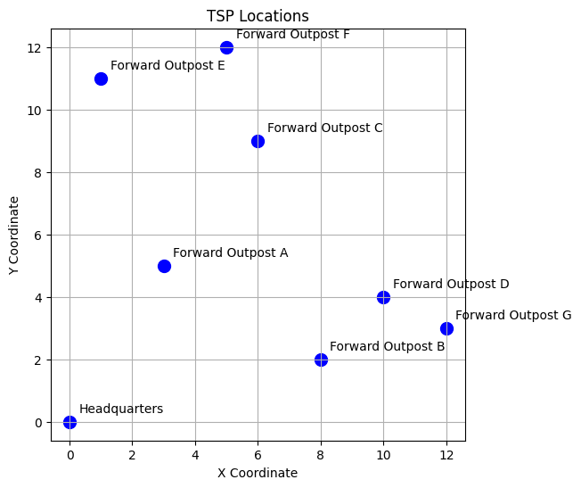

```python
import numpy as np
import dimod
import openjij as oj
import matplotlib.pyplot as plt

# 2. Problem setup: TSP
# Tour location list (outpost name, x_coordinate, y_coordinate)
locations = [
    ("Headquarters",      0,  0),
    ("Forward Outpost A", 3,  5),
    ("Forward Outpost B", 8,  2),
    ("Forward Outpost C", 6,  9),
    ("Forward Outpost D",10,  4),
    ("Forward Outpost E", 1, 11),
    ("Forward Outpost F", 5, 12),
    ("Forward Outpost G",12,  3)
]
names = [loc[0] for loc in locations]
coords = np.array([[loc[1], loc[2]] for loc in locations])
num_cities = len(locations)

# Compute the distance matrix between all locations (using Euclidean distance)
def calculate_distance_matrix(coords):
    dist_matrix = np.zeros((len(coords), len(coords)))
    for i in range(len(coords)):
        for j in range(len(coords)):
            dist_matrix[i, j] = np.linalg.norm(coords[i] - coords[j])
    return dist_matrix

distance_matrix = calculate_distance_matrix(coords)
print("TSP Distance Matrix:")
print(np.round(distance_matrix, 2))

# ----- Plotting utilities -----

# 1. Coordinate point visualization
plt.figure(figsize=(6,6))
plt.scatter(coords[:,0], coords[:,1], c='blue', s=100)
for idx, label in enumerate(names):
    plt.annotate(label, (coords[idx,0]+0.3, coords[idx,1]+0.3))
plt.title("TSP Locations")
plt.xlabel("X Coordinate")
plt.ylabel("Y Coordinate")
plt.grid(True)
plt.show()
```

# Converting the TSP Problem into a QUBO Model

We use binary variables x_i,t to represent “visiting outpost i at time step t”.

Our objective is to minimize the total path length, while satisfying two strict constraints:

Each outpost must be visited exactly once.

At each time step, only one outpost can be visited.

Therefore, the QUBO objective function can be written as:

$ \begin{aligned} H(x)\;=\;&\underbrace{\sum_{i=1}^N\sum_{\substack{j=1\\j\neq i}}^N\sum_{t=1}^N d_{ij}\;x_{i,t}\,x_{j,t+1}}_{\text{(1) Minimizing the total path length}}\\ &+\;P\;\underbrace{\sum_{i=1}^N\Bigl(\sum_{t=1}^N x_{i,t} - 1\Bigr)^{2}}_{\text{(2) Each outpost is visited exactly once}}\\ &+\;P\;\underbrace{\sum_{t=1}^N\Bigl(\sum_{i=1}^N x_{i,t} - 1\Bigr)^{2}}_{\text{(3) Only one outpost is visited at each time step}} \end{aligned} $

$ • x_{i,t}\in\{0,1\} indicates “whether outpost i is visited at time slot t”. $

$ • d_{ij} is the distance from outpost i to outpost j, and the index t+1 is handled with modulo N to form a closed loop. $

$ • P (penalty in the code) is the penalty coefficient, which should be chosen to be larger than the total sum of all distances to ensure that the constraints are strictly enforced. $

After expansion:

At each time step, exactly one outpost is visited $ P\sum_{t=1}^{N}\bigl(\sum_{i}x_{i,t}-1\bigr)^{2} = P\sum_{t=1}^{N}\Bigl[ -\sum_{i=1}^{N}x_{i,t} +2\sum_{1\le i<i’\le N}x_{i,t}\,x_{i’,t} +1\Bigr]. $

```python
# 3. Construct the QUBO model

penalty = 200
Q = {}
N = num_cities

# Objective function term: minimize the total path length
for i in range(N):              # for each departure outpost i
  for j in range(N):            #   for each arrival outpost j
    for t in range(N):          #     for each time slice t
      t_plus_1 = (t + 1) % N    #     next time slice (cyclic)
      if i != j:
        # Transition between different outposts i→j: place distance d_ij into Q[(u,v)]
        Q[(i*N + t, j*N + t_plus_1)] = distance_matrix[i,j]
      else:
        # If i == j, this represents “the same outpost from the same time to the next time”,
        # and this quadratic term should be set to 0
        Q[(i*N + t, j*N + t_plus_1)] = 0

# Constraint 1: each outpost is visited exactly once
for i in range(N):              # for each outpost i
  for t1 in range(N):           #   for all time slots t1 of this outpost
    # Linear term (diagonal term): add penalty * (-1)
    Q[(i*N + t1, i*N + t1)] = Q.get((i*N + t1, i*N + t1), 0) + penalty * (-1)

    for t2 in range(t1+1, N):  #   for different times t1 < t2 of the same outpost
      # Interaction term (quadratic term): add penalty * 2
      Q[(i*N + t1, i*N + t2)] = Q.get((i*N + t1, i*N + t2), 0) + penalty * 2

# Constraint 2: exactly one outpost is visited at each time step
for t in range(N):              # for each time slice t
  for i1 in range(N):           #   for all outposts i1
    # Linear term (diagonal term): add penalty * (-1)
    Q[(i1*N + t, i1*N + t)] = Q.get((i1*N + t, i1*N + t), 0) + penalty * (-1)

    for i2 in range(i1+1, N):   #   for different outposts i1 < i2 at the same time
      # Interaction term (quadratic term): add penalty * 2
      Q[(i1*N + t, i2*N + t)] = Q.get((i1*N + t, i2*N + t), 0) + penalty * 2
```

# Part I: Using Simulated Annealing (Simulated Annealing, SA)

SA is a heuristic algorithm based on the physical annealing process. Imagine a piece of metal that is heated and then gradually cooled; its molecules slowly transition from a random arrangement toward an ordered crystalline structure, eventually reaching a stable state with minimum energy. SA mimics this process: it starts from a random solution, and at a higher “temperature”, it accepts worse solutions (higher energy) with a certain probability, which helps the algorithm escape the trap of local optima. As the “temperature” gradually decreases, the probability of accepting worse solutions also decreases, and the algorithm eventually converges to a better solution.

```
--- SA Solution ---
Final Path:  ['Forward Outpost F', 'Forward Outpost C', 'Forward Outpost A', 'Forward Outpost B', 'Forward Outpost G', 'Forward Outpost D', 'Headquarters', 'Forward Outpost E', 'Forward Outpost F']
Total Distance: 46.29
```

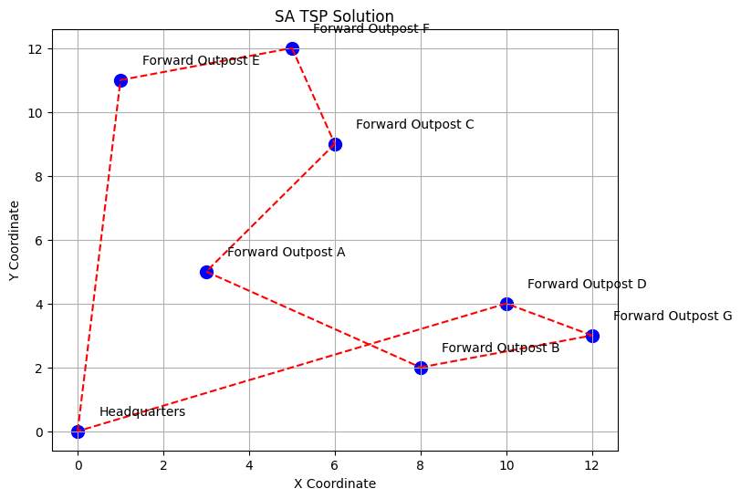

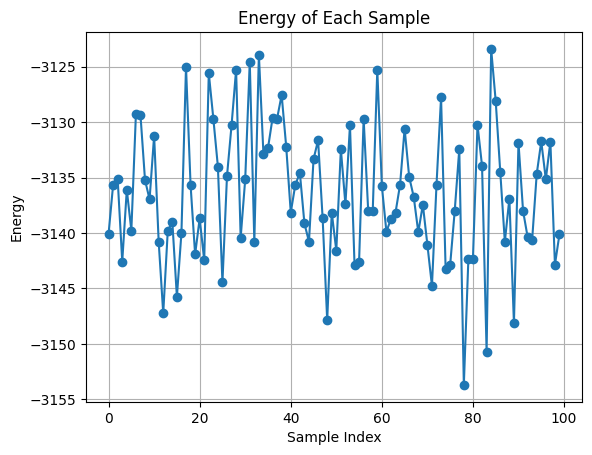

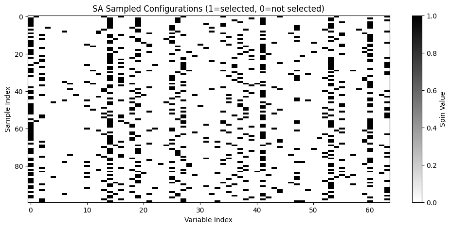

```python
# Solve TSP using SA
sampler_sa = dimod.SimulatedAnnealingSampler()
sampleset_sa = sampler_sa.sample_qubo(
    Q,
    num_reads=100  # number of independent samples
)

# Parse the best solution and reconstruct it as (time, city) pairs
best_solution_sa = sampleset_sa.first.sample
path_sa = []
for i in range(N):
    for t in range(N):
        if best_solution_sa.get(i * N + t) == 1:
            path_sa.append((t, names[i]))

# Sort by time and close the tour
path_sa.sort(key=lambda x: x[0])
final_path_sa = [city for _, city in path_sa]
final_path_sa.append(final_path_sa[0])

# Compute the total distance
total_distance_sa = 0.0
for t in range(N):
    from_city = path_sa[t][1]
    to_city   = path_sa[(t + 1) % N][1]
    i = names.index(from_city)
    j = names.index(to_city)
    total_distance_sa += distance_matrix[i, j]

print("--- SA Solution ---")
print("Final Path: ", final_path_sa)
print(f"Total Distance: {total_distance_sa:.2f}")

# Plot the SA route
plt.figure(figsize=(8, 6))
plt.title('SA TSP Solution')
plt.xlabel('X Coordinate')
plt.ylabel('Y Coordinate')
plt.grid(True)

# Plot city locations
plt.scatter(coords[:, 0], coords[:, 1], c='blue', s=100)
for idx, label in enumerate(names):
    plt.annotate(label, (coords[idx, 0] + 0.5, coords[idx, 1] + 0.5))

# Plot the connecting path
for k in range(len(final_path_sa) - 1):
    i = names.index(final_path_sa[k])
    j = names.index(final_path_sa[k+1])
    plt.plot(
        [coords[i, 0], coords[j, 0]],
        [coords[i, 1], coords[j, 1]],
        'r--'
    )
plt.show()

# Energy versus sampling order
energies = sampleset_sa.record.energy
plt.figure()
plt.plot(energies, marker='o')
plt.title("Energy of Each Sample")
plt.xlabel("Sample Index")
plt.ylabel("Energy")
plt.grid(True)
plt.show()

# Heatmap: observe all sampled binary configurations
plt.figure(figsize=(12, 5))
plt.imshow(sampleset_sa.record.sample, aspect='auto', cmap='binary')
plt.title("SA Sampled Configurations (1=selected, 0=not selected)")
plt.xlabel("Variable Index")
plt.ylabel("Sample Index")
plt.colorbar(label="Spin Value")
plt.show()
```

# Part II: Using Quantum-Inspired Simulated Annealing (SQA) - Time-Slicing Method

```
--- SQA Solution ---
Final Path: ['Forward Outpost A', 'Forward Outpost E', 'Forward Outpost B', 'Forward Outpost F', 'Forward Outpost D', 'Forward Outpost G', 'Forward Outpost C', 'Headquarters', 'Forward Outpost A', 'Forward Outpost A']
Total Distance: 64.97
```

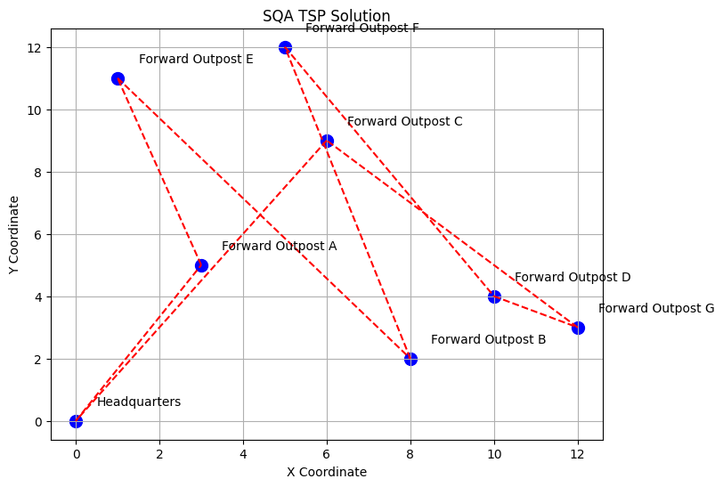

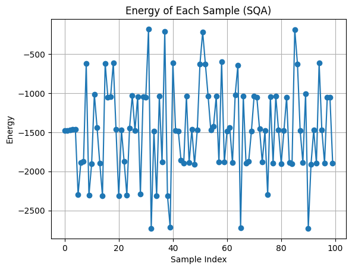

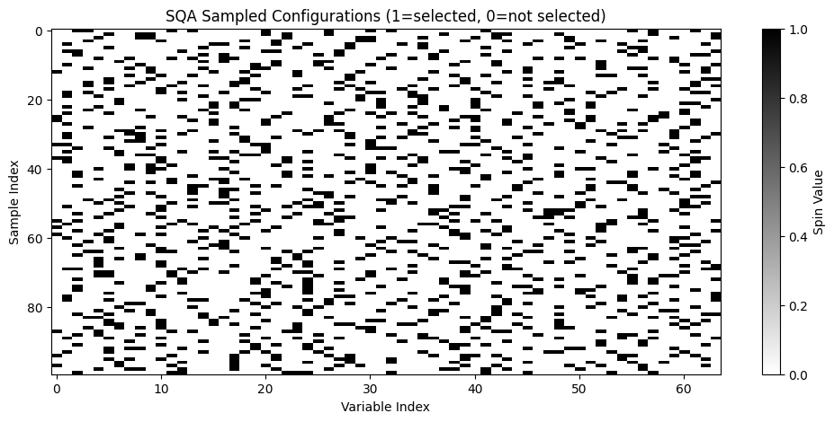

```python
# 4. Initialize SQA
sampler_sqa = oj.SQASampler()
sampleset_sqa = sampler_sqa.sample_qubo(
    Q,
    num_reads=100,
    num_sweeps=2000,
)

# Parse the best solution
best_solution_sqa = sampleset_sqa.first.sample
path_sqa = []
for i in range(N):
    for t in range(N):
        if best_solution_sqa.get(i * N + t) == 1:
            path_sqa.append((t, names[i]))

# Sort by time order
path_sqa.sort(key=lambda x: x[0])
final_path_sqa = [item[1] for item in path_sqa]
final_path_sqa.append(final_path_sqa[0])

total_distance_sqa = 0
for t in range(N):
    city_from_index = [names.index(item[1]) for item in path_sqa if item[0] == t][0]
    city_to_index = [names.index(item[1]) for item in path_sqa if item[0] == (t + 1) % N][0]
    total_distance_sqa += distance_matrix[city_from_index, city_to_index]

print("--- SQA Solution ---")
print(f"Final Path: {final_path_sqa}")
print(f"Total Distance: {total_distance_sqa:.2f}")

# Plot the SQA route
plt.figure(figsize=(8, 6))
plt.title('SQA TSP Solution')
plt.xlabel('X Coordinate')
plt.ylabel('Y Coordinate')
plt.grid(True)

plt.scatter(coords[:, 0], coords[:, 1], c='blue', s=100)
for i, txt in enumerate(names):
    plt.annotate(txt, (coords[i, 0] + 0.5, coords[i, 1] + 0.5))

for i in range(len(final_path_sqa) - 1):
    from_idx = names.index(final_path_sqa[i])
    to_idx = names.index(final_path_sqa[i+1])
    plt.plot(
        [coords[from_idx, 0], coords[to_idx, 0]],
        [coords[from_idx, 1], coords[to_idx, 1]],
        'r--'
    )
plt.show()

# Heatmap: observe all sampled binary configurations
energies_sqa = sampleset_sqa.record.energy
plt.figure()
plt.plot(energies_sqa, marker='o')
plt.title("Energy of Each Sample (SQA)")
plt.xlabel("Sample Index")
plt.ylabel("Energy")
plt.grid(True)
plt.show()

plt.figure(figsize=(12,5))
plt.imshow(sampleset_sqa.record.sample, aspect='auto', cmap='binary') # hollowed region
plt.xlabel("Variable Index")
plt.ylabel("Sample Index")
plt.title("SQA Sampled Configurations (1=selected, 0=not selected)")
plt.colorbar(label="Spin Value")
plt.show()
```

1. Comparison and Analysis

Compare the final routes found by SA and SQA. Which method finds a shorter total distance? How do their routes differ?

In terms of runtime, is there a significant difference between the two? Does this align with your professional expectations and descriptions of these two algorithms?

2. Algorithm Strategy

Try adjusting the penalty coefficient penalty. If penalty is set too low, the algorithm may find an extremely short “route” that does not visit all outposts or does not visit exactly one outpost at each time step. Which penalty value do you think best fits your patrol style?

3. Try adjusting the num_sweeps parameter of SQA. How does increasing or decreasing this value affect the results and the runtime?

Quantum Advantage of SQA

Based on your experimental results, what special advantages do you think SQA has over traditional SA in this type of complex TSP problem?